# Similarity

Anton Könneke

# Data Preparation

Before we can compare the press releases of CDU and AfD, the objects must be imported and combined into a quanteda document.

```r
knitr::opts_chunk$set(warning = FALSE, message = FALSE)
library(pacman)
p_load(tidyverse, quanteda, quanteda.textstats, readtext)
cdu <- read_csv("texts/cdu_articles.csv")
afd <- read_csv("texts/afd_articles.csv")
```

We can then take a first look at the data:

```r
head(afd)
```

| url | headline | date | author | fulltext |
| --- | --- | --- | --- | --- |
| https://www.afd.de/stephan-brandner-linker-strassenterror-wie-in-leipzig-darf-sich-nicht-wiederholen/ | Stephan Brandner: Linker Straßenterror wie in Leipzig darf sich nicht wiederholen | 3. Juni 2023 | Stephan Brandner | Am Mittwoch wurden Lina Engel und drei weitere Mitglieder der linken sogenannten „Hammerbande“ wegen Gewaltverbrechen und der Mitgliedschaft in einer kriminellen Vereinigung zu mehrjährigen Haftstrafe… |
| https://www.afd.de/alice-weidel-die-ampel-regierung-hat-das-vertrauen-der-buerger-verspielt-deutschland-braucht-neuwahlen/ | Alice Weidel: Die Ampel-Regierung hat das Vertrauen der Bürger verspielt. Deutschland braucht Neuwahlen! | 2. Juni 2023 | Alice Weidel | Im jüngsten ARD-Deutschlandtrend erreicht die AfD erneut 18 Prozent und liegt damit gleichauf mit der SPD. Darüber hinaus sind nur noch 20 Prozent der Deutschen mit der Arbeit der Bundesregierung einv… |
| https://www.afd.de/carsten-huetter-afd-ist-auf-teilrueckzahlung-staatlicher-mittel-aus-parteienfinanzierung-gut-vorbereitet/ | Carsten Hütter: AfD ist auf Teilrückzahlung staatlicher Mittel aus Parteienfinanzierung gut vorbereitet! | 2. Juni 2023 | Carsten Hütter | Der Bundesschatzmeister der AfD, Carsten Hütter, kommentiert die heute von der Verwaltung des Deutschen Bundestages an die Parteien versendete Anhörung zu der beabsichtigten Teilrücknahme der Bescheid… |
| https://www.afd.de/stephan-brandner-mehrjaehrige-haftstrafen-fuer-mitglieder-der-hammerbande/ | Stephan Brandner: Mehrjährige Haftstrafen für Mitglieder der Hammerbande | 31. Mai 2023 | Stephan Brandner | Heute wurde gegen die Linksextremistin Lina E. und drei weitere Mitglieder der sogenannten „Hammerbande“ ein Urteil verkündet. Die Bundesanwaltschaft wirft der Gruppe vor, Teil einer kriminellen Verei… |
| https://www.afd.de/mariana-harder-kuehnel-drohende-einbuergerungswelle-deutscher-pass-darf-nicht-entwertet-werden/ | Mariana Harder-Kühnel: Drohende Einbürgerungswelle: Deutscher Pass darf nicht entwertet werden! | NA | Mariana Harder-Kühnel | Dazu Mariana Harder-Kühnel, stellvertretende Bundessprecherin der Alternative für Deutschland:\n„Trotz dieser alarmierenden Entwicklungen bereitet die Ampel derzeit eine weitere Lockerung der Einbürge… |
| https://www.afd.de/tino-chrupalla-asylreform-im-interesse-der-buerger/ | Tino Chrupalla: Asylreform im Interesse der Bürger | NA | Tino Chrupalla | „Polen leitet Asylzuwanderer einfach nach Deutschland durch. Und Ministerpräsident Kretschmer ist außer Stande, die Grenze zu schützen. Bundesinnenministerin Faeser reist an, um das Versagen des Lande… |

For the AfD-Data, we have the source url, the author, the date, the fulltext and the headline.

```r
head(cdu)
```

| url | date | author | headline | subtitle | primer | text |
| --- | --- | --- | --- | --- | --- | --- |
| https://www.cducsu.de/presse/pressemitteilungen/wohneigentum-fuer-alle | 12.06.2023 | Dr. Jan-Marco Luczak | Wohneigentum für alle | CDU/CSU will Deutschland zum Land der Eigentümer machen | Deutschland ist bei der Eigentumsquote Schlusslicht in Europa. Vier von fünf Menschen wünschen sich zwar ein Eigenheim, doch nur wenige können sich diesen Traum erfüllen. Das liegt nicht nur an gestie… | „Vier von fünf Menschen in Deutschland träumen von den eigenen vier Wänden. Denn ein Eigenheim ist gelebte Freiheit, gute Altersvorsorge und macht unabhängig von steigenden Mieten. Leider können viel … |
| https://www.cducsu.de/presse/pressemitteilungen/dringender-handlungsbedarf-bei-der-verguetung-von-betreuern-und-verfahrenspflegern | 12.06.2023 | Dr. Günter Krings, Wilfried Oellers | Dringender Handlungsbedarf bei der Vergütung von Betreuern und Verfahrenspflegern | Auch Betreuungsvereine brauchen eine bessere Unterstützung | Durch die hohe Inflation und eine unzureichende Finanzierung stehen die Betreuungsvereine vor einer existenziellen Bedrohung. Zudem hat das Gesetz zum Bürgergeld die Vergütungssituation der Betreuer u… | Günter Krings: „Betreuerinnen und Betreuer sowie nicht zuletzt die vielen Betreuungsvereine in unserem Land leisten einen wichtigen Beitrag für Menschen, die sich nicht um ihre eigenen Angelegenheiten… |
| https://www.cducsu.de/presse/pressemitteilungen/mit-praeventiven-konzepten-gewalt-gegen-frauen-verhindern | 11.06.2023 | Andrea Lindholz | Mit präventiven Konzepten Gewalt gegen Frauen verhindern | NA | Laut einer repräsentativen Studie von Plan International Deutschland findet jeder dritte junge Mann Gewalt gegen Frauen akzeptabel. Dazu erklärt die stellvertretende Vorsitzende der CDU/CSU-Fraktion i… | „Das Ergebnis dieser aktuellen Studie ist erschreckend. Bedauerlicherweise passt sie zu den schon bestehenden Erkenntnissen, dass in Deutschland jede dritte Frau mindestens einmal in ihrem Leben Opfer… |
| https://www.cducsu.de/presse/pressemitteilungen/beschluss-zur-eu-asylreform-reicht-nicht-aus | 09.06.2023 | Andrea Lindholz | Beschluss zur EU-Asylreform reicht nicht aus | Bis neue EU-Asylregeln wirken, muss Ampel nationale Maßnahmen zur Begrenzung der irregulären Migration ergreifen | Die EU-Innenminister haben sich auf eine Reform des Gemeinsamen Europäischen Asylsystems (GEAS) geeinigt. Dazu erklärt die Stellvertretende Vorsitzende der CDU/CSU-Bundestagsfraktion, Andrea Lindholz: | „Mit dem Beschluss der EU-Innenminister zur GEAS-Reform kann man insgesamt nicht zufrieden sein. Die Ergebnisse reichen nicht aus, um die Asylmigration in die EU auf Dauer wirksam zu ordnen und zu beg… |
| https://www.cducsu.de/presse/pressemitteilungen/von-der-wirtschaftslokomotive-zum-bummelzug | 09.06.2023 | Julia Klöckner | Von der Wirtschaftslokomotive zum Bummelzug | Deutschland für OECD nur noch Schlusslicht unter den Industrieländern | Angesichts der Prognose der Industrieländer-Organisation OECD für die Weltwirtschaft und den wirtschaftlich düsteren Aussichten für Deutschland erklärt die wirtschaftspolitische Sprecherin der CDU/CSU… | „Deutschland stürzt wirtschaftlich ab – und die Bundesregierung scheint das nicht zu stören. Während die Weltwirtschaft und die EU ein wirtschaftliches Wachstum erwarten können, sinken die Aussichten … |
| https://www.cducsu.de/presse/pressemitteilungen/faeser-muss-der-eu-asylpolitik-jetzt-liefern | 07.06.2023 | Andrea Lindholz | Faeser muss in der EU-Asylpolitik jetzt liefern | NA | Anlässlich des Treffens der EU-Innenminister zur Asylpolitik an diesem Donnerstag können Sie die Stellvertretende Vorsitzender der CDU/CSU-Bundestagsfraktion, Andrea Lindholz, gerne wie folgt zitieren… | „Die Asylzuwanderung nach Deutschland bleibt auf sehr hohem Niveau: Im Mai wurden fast 22.000 Asylerstanträge gestellt. Das sind 11,8 Prozent mehr als im April und 70,5 Prozent mehr als im Mai 2022. I… |

For the CDU we also have a subtitle and a primer. We care only for the date and the fulltext for now, but in order to make the data extendable, all column names should be harmonised by now already.

```r
colnames(afd)
```

```
## [1] "url"      "headline" "date"     "author"   "fulltext"
```

```r
colnames(cdu)
```

```
## [1] "url"      "date"     "author"   "headline" "subtitle" "primer"   "text"
```

```r
cdu <- cdu %>%
  rename(fulltext = text)
```

We also need to convert the strings holding the dates to date variables.

```r
cdu <- cdu %>%
  mutate(date = as.Date(date, format = "%d.%m.%Y"))

Sys.setlocale(locale = "de_DE")
```

```
## [1] "de_DE/de_DE/de_DE/C/de_DE/en_US.UTF-8"
```

```r
afd <- afd %>%
  mutate(day = str_extract(date, "^\\d+"),
         mon = str_match(date, "(?<=\\d{1}\\.\\s)\\w*")[,1],
         year = str_extract(date, "\\d{4}$"),
         date_fmt = paste(year, mon, day, sep =  "-"),
         date = as.Date(date_fmt, format = "%Y-%B-%e"))
Sys.setlocale(locale = "en_US")
```

```
## [1] "en_US/en_US/en_US/C/en_US/en_US.UTF-8"
```

Now we can now merge the two datasets together.

```r
cdu$source = "CDU"
afd$source = "AfD"

press_rel <- bind_rows(cdu, afd)
```

By adding an identifier for the month, we can later on compare trends over time on a month-grouped dataset that will offer sufficient observations for relatively stable estimations.

```r
press_rel <- press_rel %>%
  mutate(month = lubridate::round_date(date, "month"))
```

# Frequency

Lets start by simply examining the activity of both parties over time:

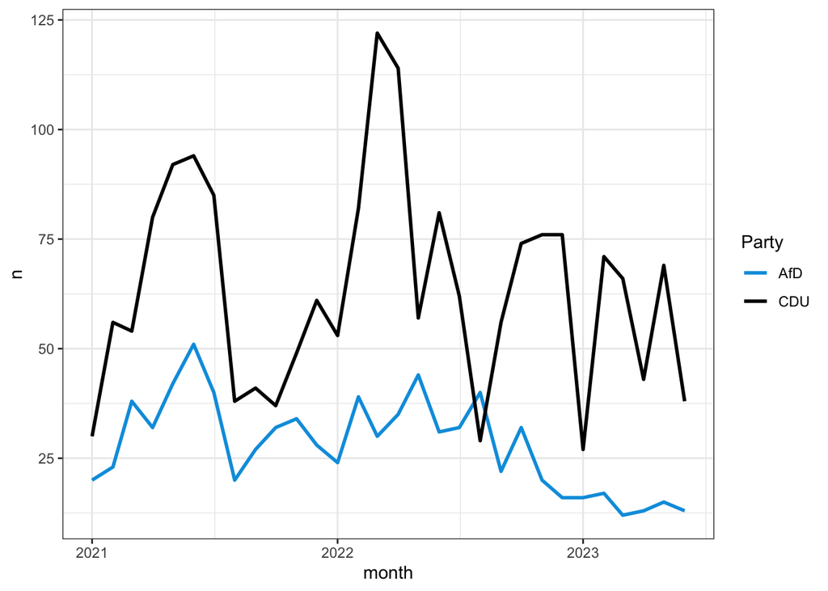

```r
party_colors <-
  scale_color_manual("Party",
                     values = c("AfD" = "#009ee0", "CDU" =  "black"))

press_rel %>%
  filter(month >= lubridate::ymd("2021-01-01")) %>%
  summarise(n = n(), .by = c(month, source)) %>%
  ggplot(aes(month, n, color = source))+
  geom_line(size = 1)+
  party_colors+
  theme_bw()
```

# Keyness

Now to the text analysis: lets begin by identifying words that are best able to predict whether we are reading a CDU-Text or an AfD-Text. The typical quanteda workflow is to create a corpus, clean the tokens and then create a document- feature matric (dfm).

```r
press_corp <- corpus(press_rel, text_field = "fulltext")
press_tok <-
  tokens(
    press_corp,
    remove_punct = TRUE,
    remove_numbers = TRUE,
    remove_symbol = TRUE
  ) %>%
  tokens_tolower()
press_tok <- tokens_remove(press_tok, pattern = c(stopwords("de")))
press_tok <- tokens_remove(
  press_tok,
  pattern =
    as.character(tokens(
      paste0(unique(press_rel$author), collapse = " "),
      remove_punct = TRUE,
      remove_numbers = TRUE,
      remove_symbol = TRUE
    ) %>%
      tokens_tolower())
)
press_dfmat <- dfm(press_tok) %>%
              dfm_trim(min_termfreq = 10, termfreq_type = "count",
                       max_docfreq = 0.1, docfreq_type = "prop")
```

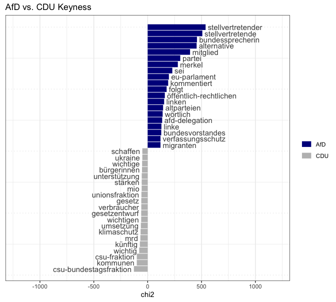

```r
textstat_keyness(dfm_group(press_dfmat, groups = source)) %>%
  quanteda.textplots::textplot_keyness()+
  coord_cartesian(xlim = c(-1200, 1200))+
  ggtitle("AfD vs. CDU Keyness")
```

# Similarity

Lets now compute the similarity of the documents.

```r
textstat_simil(dfm_group(press_dfmat, groups = source),
               margin = "documents",
               method = "correlation") %>%
  head()
```

```
##           AfD       CDU
## AfD 1.0000000 0.5616879
## CDU 0.5616879 1.0000000
```

There is a certain degree of similarity, but we can not really interpret it by now. After all, both sources talk in the same language about the same topic (politics). Hence, it is not surprising that we find some correlation. However, what we can interpret are evolutions of this correlation. Does it change over time?

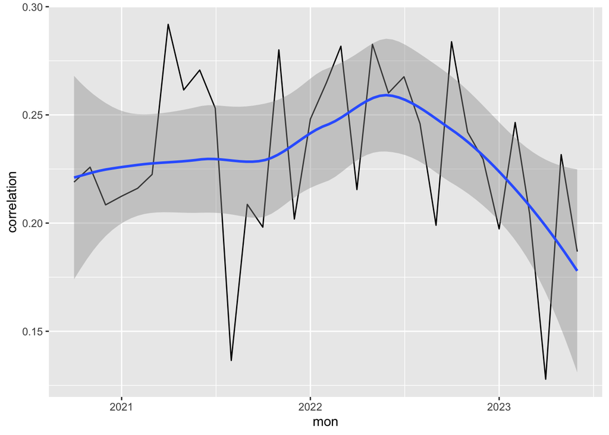

```r
press_dfmat$party_mon = paste(press_dfmat$source, press_dfmat$month, sep = "_")

simil_mon <- textstat_simil(
  dfm_weight(
    dfm_group(press_dfmat, groups = party_mon),
    "prop"),
               margin = "documents",
               method = "correlation") %>%
  as.data.frame() %>%
  mutate(d1p = str_sub(document1, 1L, 3L),
         d2p = str_sub(document2, 1L, 3L),
         d1d = str_sub(document1, 5L, 14L),
         d2d = str_sub(document2, 5L, 14L)) %>%
  filter(d1p == "AfD" & d2p == "CDU") %>%
  filter(d1d == d2d) %>%
  mutate(mon = lubridate::ymd(d1d))

ggplot(simil_mon, aes(mon, correlation))+
  geom_line()+
  geom_smooth()
```